[figure not shown]

# Version Control with Git and GitHub

Git for Data Scientist

Fathom Training

03 November, 2021

# Git

## What are Git and GitHub?

[figure not shown]

Git allows users to track changes to files and record snapshots of these changes as they evolve with the development of the project. Git also allows branching, wherein you can work on multiple versions of the same project independently of one another, combining versions when and if you want to. You can do this locally using Git, but where the technology really shines is in combination with cloud-based platforms like GitHub and GitLab. It allows people to see your work, sync up with your projects and perhaps make changes.

GitHub is a platform that enables cloud storage of:

1. the record of changes made in a project (AKA the diff);
2. the files and folders that make up the project (AKA the repository); and
3. different versions of the project (AKA branches),
4. enables collaboration with teammates through pull requests,
5. enables continuous integration/deployment (CI/CD) (AKA deploys to a cloud)

Storing your work in the cloud has a number of other benifits:

- usability and accessibility
- security
- convenience
- multiple users

Check out the git [cheatsheet](https://education.github.com/git-cheat-sheet-education.pdf) for all of the most useful Git commands!

[figure not shown]

## The perks of using Git

- *Exposure*: if somebody needs to see your work or if you want them to try out your code, they can get it from GitHub
- *Collaboration*: if you have to collaborate on data analysis or code development
- *Website*: you get a decent list of all files and directories in your project
- *Version control*: you can track the history of the project in the commit when working with others

## Bash commands

Some essential terminal commands for working with Git:

- `cd`: change directory, used to change the current working directory
- `touch`: to create new file
- `mkdir`: create a directory
- `ls`: list content of a directory
- `grep`: search
- `man`: print manual or get help for a command
- `pwd`: print working directory
- `rmdir`: remove directory
- `cat`: read a file, create a file, and concatenate files

# Getting started

To get started, you will need to synchronise GitHub with your local machine. GitHub requires you to log in with your username and password. The first thing that you need to do is create yourself a Github account. Create a free GitHub account [here](https://github.com).

**Fact: You want to select a memorable (and sensible!) user name — this is something that you will continue to use throughout your career.**

## Installing Git

### Is Git already installed?

Go to the shell or terminal and enter `which git` to request the path to your Git executable:

```
$ which git
```

Type git –version to see which version is installed:

```
$ git --version
```

If this runs without any errors, that’s great! You already have Git installed. Otherwise, install Git using the steps below.

## Git for Linux and macOS

- Git is installed on Linux and macOS computers as a [command line option](https://www.atlassian.com/git/tutorials/install-git)
- Installing Git on Mac

To elicit an offer to install Git on mac:

```
$ git --version
$ git config
```

- Installing Git on Linux

Ubuntu or Debian Linux:

```
$ sudo apt-get install git
```

Fedora or RedHat Linux:

```
$ sudo yum install git
```

- Installing GitHub on Windows:
  1. Open the [Git website](https://gitforwindows.org/)
  2. Click the ‘Download’ link
  3. The download should automatically start
  4. Start the installation from the download folder
  5. In the ‘Select Components’ window, leave all default options checked
  6. Click the ‘Install’ button

## Git configuring

[figure not shown]

Now that you have Git installed on your local machine, you are required to do a few more things to customize your Git environment. You are only required to do this once and can change them at any time by repeating the commands. Git comes with a `git config` command allowing you to get/set configuration variables that controls how Git looks and operates.

You can view all of your settings and their location by using:

```bash
$ git config --list --show-origin
```

After installing Git, you need to set your user name and email address. This is essential as every Git commit uses this information:

```bash
$ git config --global user.name "My username"
$ git config --global user.email example@gmail.com
```

It is also possible to configure the default text editor that will be used when Git needs you to type a message. If we do not alter the configuration, Git uses your operating systems default editor. For example, if you want to use Emacs as your text editor:

```bash
$ git config --global core.editor emacs
```

## Setting up your PAT

Instead of passwords, Git offers the use of personal access tokens (PAT). GitHub wants to make their platform as secure as possible to avoid accounts being hacked. By forcing users to think about who has right to a GitHub repository, the types of fine grained repository access users should have and eliminating the possibility of weak passwords being used, the cloud-based Git platform should be more secure.

Steps to generate a GitHub personal access token:

1. Log into [GitHub](https://github.com/login) with your username and password
2. Navigate to your GitHub account settings
3. Scroll down and click ‘Developer settings’ in the list of links to the left
4. Click the Personal access tokens link
5. Click the ‘Generate new token’ button
6. Add a ‘Note’ to describe the tokens usage
7. Set an expiration date for the GitHub personal access token
8. Select the appropriate authentication scope
9. Click the ‘Generate token’ button

**Before navigating away from the page, copy your personal access token. The token’s alphanumeric value will not be displayed again. The next time that you push or commit to GitHub, provide the personal access token instead of the password - We will explore these throughout this session.**

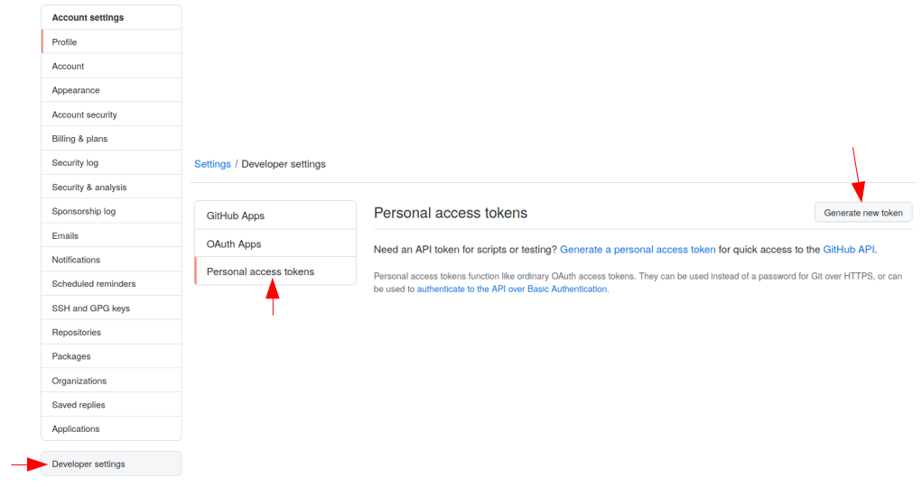

## SSH (Secure Shell)

SSH allows you to connect and authenticate to remote servers and services. With SSH keys, you can connect to GitHub without supplying your username and personal access token at each visit and with each commit. To set this up, we will need to generate a new SSH key and add it to the ssh-agent. This SSH key must be added to your GitHub account before using the key to authenticate.

Generating a new SSH key:

1. Open the terminal
2. This creates a new SSH key

```bash
$ ssh-keygen -t ed25519 -C "your_email@example.com"
```

3. Press `Enter`, the default file location will be applied
4. At the prompt, when asked to enter a secure passphrase, Press `Enter`. When asked to repeat the passphrase Press `Enter` again

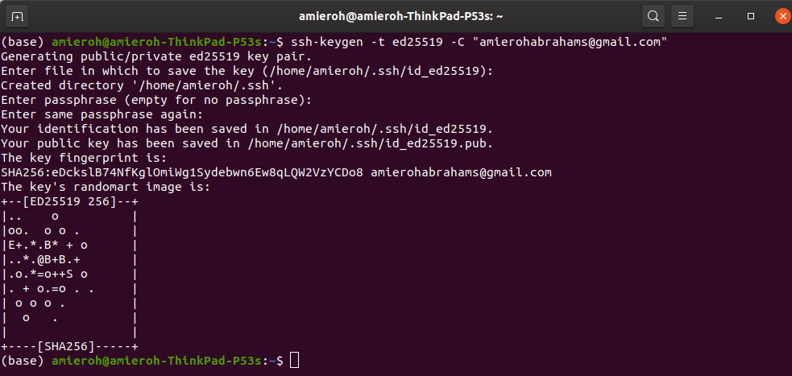

Adding your SSH key to te ssh-agent:

1. Start ssh-agent in the background

```bash
$ eval "$(ssh-agent -s)"
```

2. Add SSH private key to the ssh-agent

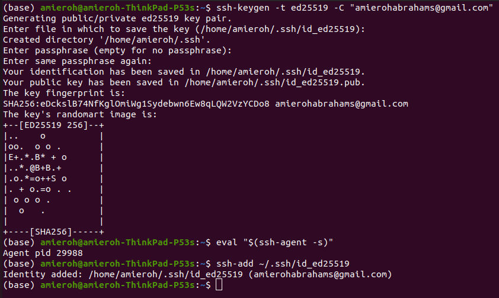

```bash
$ ssh-add ~/.ssh/id_ed25519
```

Adding SSH key to your account on GitHub:

1. Copy the SSH public key

```bash
cat ~/.ssh/id_ed25519.pub
```

2. Click on your GitHub profile and click **Settings**
3. In the user settings sidebar, click **SSH and GPG keys**
4. Click **New SSH key**
5. Paste your key into the **Key** field
6. Add SSH key

[figure not shown]

## How Do I speak GitHub?

Common terms we will need to understand while using GitHub

- **Repository (repo)**: a folder where files and version histories are stored
- **Branch**: a workspace where you can make changes that won’t affect the live site
- **Commits**: a saved record of changes made to a file
- **Pull requests**: you’re proposing your changes and requesting that someone review and pull in your contribution and merge them into their branch
- **Issues**: allows users to report new tasks and content fixes
- **Forks**: copying a repository allowing you to freely experiment with changes without affecting the original project

## Git commands

Some essential git commands:

- `git config`: optional configuration step. If you are configuring Git for use on your local machine, you might want to associate all Git repositories with your email address. You can use the `--global` option for this configuration
- `git init`: turns a directory into an empty Git repository
- `git add`: adds all the files to the staging area for Git. Pro tip: use the `.` wildcard to add all files in the directory, e.g. `git add .`.
- `git commit`: record the changes made to the files to a local repository and adding a sensible commit message using the `-m` flag
- `git status`: returns the current state of a repository
- `git branch`: determine what branch the local repository is on, add a new branch, or delete a branch
- `git checkout`: to start working in a different branch, use git checkout to switch branches
- `git merge`: integrate branches together. git merge combines the changes from one branch to another branch
- `git remote`: connect a local repository with a remote repository
- `git clone`: create a local working copy of an existing remote repository
- `git pull`: get the latest version of a repository
- `git push`: sends local commits to the remote repository
- `git log`: show the chronological commit history for a repository
- `git rm`: remove files or directories from the staging area
- `git rebase -- d`: during playback the commit will be discarded
- `git rebase -- p`: leave the commit as is
- `git rebase -- x`: during playback executes a command line shell script on each commit

[figure not shown]

Original content developed by [Fathom Data](https://www.fathomdata.dev/).